# Untitled

CCranney

5/22/2018

# Introduction

Since their discovery in 1928, antibiotics have played a key role in the treatment and prevention of bacterial infections. Antibiotics are a class of molecules that can inhibit the growth of or destroy bacteria or other microorganisms. They are largely produced by organisms such as fungi to kill or otherwise ward off competing or harmful microorganisms. To put it simply, antibiotics have the capacity to significantly diminish microorganism presence in the human body while minimally harming said individual. When harvested for medicinal use, antibiotics have the unparalleled capacity to treat infections that could prove hazardous to human health.

While previously discovered antibiotics have proven invaluable in medicinal practice, a growing number of superbugs resistant to these antibiotics are greatly diminishing their effectiveness. As such, the development of new antibiotics is a critical challenge in modern medicine. “A difficult problem in antibiotics research is that of sequencing newly discovered antibiotics, or determining the order of amino acids making up the antibiotic peptide.”

The composition of most antibiotics varies greatly from the sequences of known typical polypeptides. There are three main differences. First, many antibiotics are circular peptides, not linear. Without a specific beginning or end, these “cyclopeptides” can be difficult to sequence. Second, organisms that produce cyclopeptides do not always do so through the means described by the Central Dogma of Molecular Biology, which states that DNA makes RNA which makes proteins. And lastly, because these cyclopeptides are created through a mechanism independent of the Central Dogma, additional amino acids can be incorporated into their structure that are not included in the 20 proteinogenic amino acids. This increases the number of viable amino acids to something closer to 100.

These differences make sequencing cyclopeptides something of a challenge to bioinformaticians. Normally polypeptide compositions are determined via reliance on databases of known polypeptides or on DNA sequences that coincide with the polypeptide. Because very few cyclopeptides have been sequenced and because they don’t directly rely on DNA to be produced, one must rely on de novo sequencing techniques to determine their sequence.

Most de novo cyclopeptide sequencing techniques rely on expensive machinery to function. The ideal scenario would be to sequence a cyclopeptide from data produced by a mass spectrometer. A mass spectrometer shatters molecules into pieces and then weighs the resulting fragments in daltons (Da). In sequencing cyclopeptides, one would shatter several copies of a cyclopeptide and use the resulting fragments to reconstruct the cyclopeptide. Unfortunately, mass spectrometry data is both incomplete and impure. Something close to two thirds of data is false data, and of the third that is accurate only a portion of the total possible cyclopeptide fragments are represented. Below is an example cyclopeptide, Tyrocidine B1:

> Val* – Lys – Leu – Phe – Pro – Trp – Phe – Asn – Gln – Tyr

The single-character sequence of Tyrocidine B1 is **VKLFPWFNQY**, though K and Q are replaced by Z and L is replaced by X in my code, as they share weights with other amino acids. Note that this is a circular peptide, thus **V** is not the start of the peptide, it is simply the one I chose to begin on.

### Experimental Data Set for Tyrocidine B1:

[output not shown]

### Values from the Theoretical Spectrum of Tyrocidine B1 that appear in the Experimental Spectrum:

```
## [406.3, 431.2, 448.3, 486.3, 488.2, 505.3, 544.2, 545.3, 632.0, 672.5, 673.3, 691.4, 692.4, 746.5, 771.6, 819.4, 836.3, 876.5, 918.4, 933.4, 934.7, 935.5, 966.2, 1061.5, 1063.4, 1079.2, 1096.5, 1176.6, 1195.4, 1210.4, 1224.6]
```

The challenge is: Can you reconstruct Tyrosidine B1 from the Experimental Spectrum given above (without knowing in advance which ones correspond to the Theoretical Spectrum)? That is the present challenge of sequencing cyclopeptides.

All data and concepts taken from the book Bioinformatics Algorithms: An Active Learning Approach, chapter 4.

# My Algorithm

Presently, all attempts to sequence cyclopeptides rely on “branch-and-bound” methods to do so. Amino acids are added to “candidate” peptides that grow with each addition, and after each addition all peptides that do not fit the experimental spectrum are discarded. Sadly, such methods require the bulk of mass spectrometry data to be accurate representations of the cyclopeptide. As this requirement presently cannot be presently met, a new algorithm is required to succeed. Here I will explain the steps and concepts behind the algorithm I have developed.

Step one, predicting the weight of the full cyclopeptide. While difficult, cyclopeptide sequencing has one distinct advantage over linear peptide sequencing. When the weight of any segment of the cyclopeptide is subtracted from the full weight, the result is the value of the “opposite” strand of the cyclopeptide. In other words, one can predict additional fragments of the cyclopeptide. Successfully “drawing” the cyclopeptide circle requires knowing the full length (or in this case, weight) of the circle first.

In my code, I divided this step into two parts. In the first part, I add all data points of the experimental spectrum to every other data point. If the two data points happen to be opposite ends of the cyclopeptide sequence, their addition would equate the size of the full cyclopeptide. Because several of the true data points are so paired, the size of the full cyclopeptide will appear more often than a random value. After choosing frequently appearing segments, this step produces several candidate cyclopeptide weights. The second part uses known amino acid weights to normalize and further process the candidate weights. This part relies on the assumption that several data points in the experimental spectrum are short a single amino acid. Should the assumption prove true, then several data points merely require the addition of the missing amino acid weight to equal the full cyclopeptide weight. All such candidate data points are paired with their respective amino acid for each candidate full weight. By taking the average of the data points with their respective amino acid weights, the candidate full weight can be normalized. All candidate full weights that have few to no data points that are one amino acid short are no longer considered in the final evaluation.

The end result is still an approximation, and steps will be required to account for any inaccuracy. However, one of the end results should be within 0.2 Daltons or so of the actual full weight of the cyclopeptide.

Step two is where things get tricky and will require some background explanations. Visuals will be provided.

As stated previously, all currently proposed algorithms designed to sequence cyclopeptides require the addition of amino acids to growing candidate polypeptide chains. This algorithm requires looking at a cyclopeptide from a slightly different angle. The following is a pie chart representation of Tyrocidine B1, the cyclopeptide for which I have mass spec data. Different colors correspond to different amino acid weights, some of which have duplicates. Weights are represented by length, and the full length of the circle is approximately 1322.7.

*Note: I didn’t notice the symmetry of this cyclopeptide until I created this visual. It probably relates to the function of the cyclopeptide, but I’m not sure if the pattern would reliably extend to other cyclopeptides in such a way as to use it in sequencing cyclopeptides.

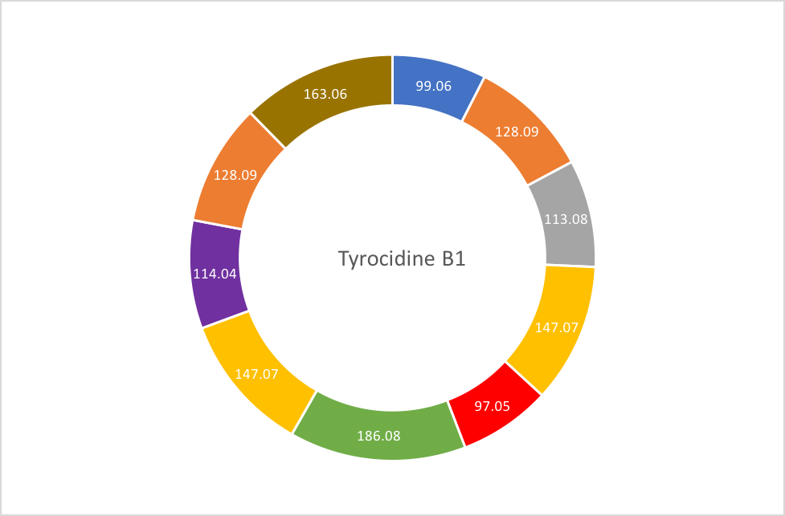

Rather than look at the cyclopeptide as a series of weights, I have found it helpful to place emphasis on the places between amino acids, or the “junctions” of the cyclopeptide. To aid in this consideration, I numbered each junction, as demonstrated in the following visual. In looking at a cyclopeptide from this angle, each true data point represents two junctions. For example, the data point 405.19 (NQY, or 114.04+128.09+163.06) would represent junctions 7 and 10. The data point 99.06 (V) would represent junctions 1 and 10.

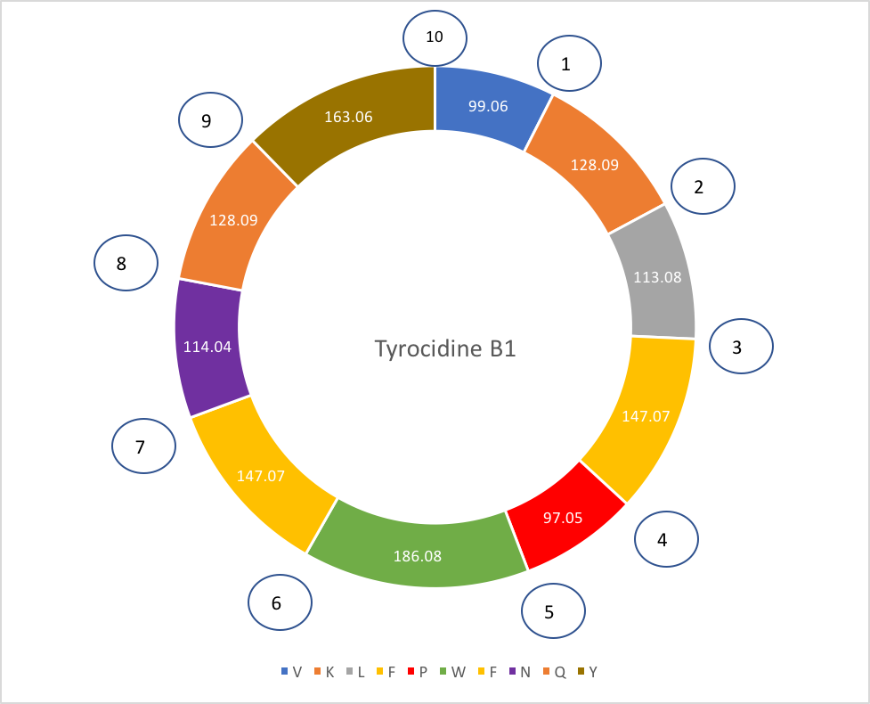

Note that, for each 2-junction pairing, there are technically two data points that could match. For the above example of NQY, the opposite strand of NQY (VKLFPWF, or 917.5) would also represent junctions 7 and 10. Fortunately, once the full sequence has been predicted, both data points can be represented by a single data point (dataPoint1 = fullWeight-dataPoint2).

From this perspective, several patterns become clear. It is evident that all junctions are touched upon by several data points (the lowest is junction 9, which is touched on by 4 data points in the experimental spectrum, while the highest is 3, which is touched on by 8). In terms of sequencing the cyclopeptide, this information is invaluable.

Sequencing the cyclopeptide requires analyzing and comparing the distances between junctions. Between any two neighboring junctions is a distance corresponding to an amino acid weight. In predicting the full weight of the cyclopeptide earlier, several candidate amino acids were determined. Each of these amino acids, then, represents two neighboring junctions (V represents junctions 1 and 10, P represents junctions 4 and 5 etc.).

Smaller data points, such as amino acids, are more likely to appear at the end of larger data points. Furthermore, each data point must start and end with amino acids that neighbor the junctions represented by that data point. For example, each data point ending at junction 4 must include an amino acid neighboring junction 4. That data point’s opposite must include the amino acid on the other side of junction 4.

Using this logic, the relative distance between further junctions can also be calculated. Take, for example, Valine (V), represented by the length 99.06 (blue) in the above illustration. Valine represents junctions 1 and 10. In our experimental spectrum, we have several cyclopeptide fragments who either neighbor or end in Valine. If a data point ends in Valine, it’s opposite fragment must neighbor Valine. To illustrate, the fragment VKLFPWF (junctions 10,7) has Valine at one end. NQY, the opposite fragment of VKLFPWF (also junctions 10,7), immediately neighbors Valine. As such, if one were to add Valine to NQY, it would result in another true data point, NQYV (junctions 1,7). Thus, by “flipping” a data point (VKLFPWF) and “adding” Valine, one would get another data point (NQYV). The relationship between these two data points is telling – they overlap over Valine (junctions 1,10) and meet at a completely different junction, namely junction 7.

My present algorithm is an attempt to recreate this scenario for each given amino acid, piece together frequently occurring themes, and account for the variables that make the theory less straightforward. For example, in our previous example the amino acid F appears twice in the cyclopeptide chain. Thus, the “flip and add” technique would work too well, providing matching data points to the two separate amino acids and combining them into one list. Also, lining up the “flip and add” pairings in the proper orientation is no small feat. In summary, this theory provides useful puzzle pieces that can be used to reconstruct a cyclopeptide. The challenge is figuring out how to put them together properly. My code is my present attempt to do so, with fairly successful results that I am trying to improve upon.